# Risk Factor Analysis

## Outcome Variable

**Outcome Variable:** y_rate_haz

## Predictor Variables

**Intervention Variable:** predfeed3

**Adjustment Set:**

- arm
- sex
- month
- brthmon
- W_mage
- meducyrs
- feducyrs
- hhwealth_quart
- hfoodsec
- W_mhtcm
- W_mwtkg
- W_mbmi
- vagbrth
- W_gagebrth
- W_birthwt
- W_birthlen
- W_nrooms
- W_nchldlt5
- W_parity
- impfloor
- impsan
- safeh20
- delta_W_mage
- delta_meducyrs
- delta_feducyrs
- delta_hhwealth_quart
- delta_hfoodsec
- delta_W_mhtcm
- delta_W_mwtkg
- delta_W_mbmi
- delta_vagbrth
- delta_W_gagebrth
- delta_W_birthwt
- delta_W_birthlen
- delta_W_nrooms
- delta_W_nchldlt5
- delta_W_parity
- delta_impfloor
- delta_impsan
- delta_safeh20

## Stratifying Variables

The analysis was stratified on these variable(s):

- agecat
- studyid
- country

## Data Summary

| agecat | studyid | country | predfeed3 | n_cell | n | outcome_variable |
| --- | --- | --- | --- | --- | --- | --- |
| 0-3 months | ki0047075b-MAL-ED | BANGLADESH | 1 | 193 | 237 | y_rate_haz |
| 0-3 months | ki0047075b-MAL-ED | BANGLADESH | 0 | 44 | 237 | y_rate_haz |
| 0-3 months | ki0047075b-MAL-ED | BRAZIL | 1 | 73 | 147 | y_rate_haz |
| 0-3 months | ki0047075b-MAL-ED | BRAZIL | 0 | 74 | 147 | y_rate_haz |
| 0-3 months | ki0047075b-MAL-ED | INDIA | 1 | 113 | 164 | y_rate_haz |
| 0-3 months | ki0047075b-MAL-ED | INDIA | 0 | 51 | 164 | y_rate_haz |
| 0-3 months | ki0047075b-MAL-ED | NEPAL | 1 | 81 | 153 | y_rate_haz |
| 0-3 months | ki0047075b-MAL-ED | NEPAL | 0 | 72 | 153 | y_rate_haz |
| 0-3 months | ki0047075b-MAL-ED | PERU | 1 | 168 | 262 | y_rate_haz |
| 0-3 months | ki0047075b-MAL-ED | PERU | 0 | 94 | 262 | y_rate_haz |
| 0-3 months | ki0047075b-MAL-ED | SOUTH AFRICA | 1 | 58 | 203 | y_rate_haz |
| 0-3 months | ki0047075b-MAL-ED | SOUTH AFRICA | 0 | 145 | 203 | y_rate_haz |
| 0-3 months | ki0047075b-MAL-ED | TANZANIA, UNITED REPUBLIC OF | 1 | 57 | 197 | y_rate_haz |
| 0-3 months | ki0047075b-MAL-ED | TANZANIA, UNITED REPUBLIC OF | 0 | 140 | 197 | y_rate_haz |
| 0-3 months | ki1000109-EE | PAKISTAN | 1 | 31 | 31 | y_rate_haz |
| 0-3 months | ki1000109-EE | PAKISTAN | 0 | 0 | 31 | y_rate_haz |
| 0-3 months | ki1113344-GMS-Nepal | NEPAL | 1 | 378 | 456 | y_rate_haz |
| 0-3 months | ki1113344-GMS-Nepal | NEPAL | 0 | 78 | 456 | y_rate_haz |
| 0-3 months | kiGH5241-JiVitA-3 | BANGLADESH | 1 | 10705 | 11852 | y_rate_haz |
| 0-3 months | kiGH5241-JiVitA-3 | BANGLADESH | 0 | 1147 | 11852 | y_rate_haz |
| 0-3 months | kiGH5241-JiVitA-4 | BANGLADESH | 1 | 145 | 160 | y_rate_haz |
| 0-3 months | kiGH5241-JiVitA-4 | BANGLADESH | 0 | 15 | 160 | y_rate_haz |
| 3-6 months | ki0047075b-MAL-ED | BANGLADESH | 1 | 184 | 225 | y_rate_haz |
| 3-6 months | ki0047075b-MAL-ED | BANGLADESH | 0 | 41 | 225 | y_rate_haz |
| 3-6 months | ki0047075b-MAL-ED | BRAZIL | 1 | 93 | 186 | y_rate_haz |
| 3-6 months | ki0047075b-MAL-ED | BRAZIL | 0 | 93 | 186 | y_rate_haz |
| 3-6 months | ki0047075b-MAL-ED | INDIA | 1 | 146 | 206 | y_rate_haz |
| 3-6 months | ki0047075b-MAL-ED | INDIA | 0 | 60 | 206 | y_rate_haz |
| 3-6 months | ki0047075b-MAL-ED | NEPAL | 1 | 112 | 226 | y_rate_haz |
| 3-6 months | ki0047075b-MAL-ED | NEPAL | 0 | 114 | 226 | y_rate_haz |

[output cut: 130 more lines]

The following strata were considered:

- agecat: 0-3 months, studyid: ki0047075b-MAL-ED, country: BANGLADESH
- agecat: 0-3 months, studyid: ki0047075b-MAL-ED, country: BRAZIL
- agecat: 0-3 months, studyid: ki0047075b-MAL-ED, country: INDIA
- agecat: 0-3 months, studyid: ki0047075b-MAL-ED, country: NEPAL
- agecat: 0-3 months, studyid: ki0047075b-MAL-ED, country: PERU
- agecat: 0-3 months, studyid: ki0047075b-MAL-ED, country: SOUTH AFRICA
- agecat: 0-3 months, studyid: ki0047075b-MAL-ED, country: TANZANIA, UNITED REPUBLIC OF
- agecat: 0-3 months, studyid: ki1000109-EE, country: PAKISTAN
- agecat: 0-3 months, studyid: ki1113344-GMS-Nepal, country: NEPAL
- agecat: 0-3 months, studyid: kiGH5241-JiVitA-3, country: BANGLADESH
- agecat: 0-3 months, studyid: kiGH5241-JiVitA-4, country: BANGLADESH
- agecat: 12-15 months, studyid: ki0047075b-MAL-ED, country: BANGLADESH
- agecat: 12-15 months, studyid: ki0047075b-MAL-ED, country: BRAZIL
- agecat: 12-15 months, studyid: ki0047075b-MAL-ED, country: INDIA
- agecat: 12-15 months, studyid: ki0047075b-MAL-ED, country: NEPAL
- agecat: 12-15 months, studyid: ki0047075b-MAL-ED, country: PERU
- agecat: 12-15 months, studyid: ki0047075b-MAL-ED, country: SOUTH AFRICA
- agecat: 12-15 months, studyid: ki0047075b-MAL-ED, country: TANZANIA, UNITED REPUBLIC OF
- agecat: 12-15 months, studyid: ki1000109-EE, country: PAKISTAN
- agecat: 12-15 months, studyid: ki1113344-GMS-Nepal, country: NEPAL
- agecat: 12-15 months, studyid: kiGH5241-JiVitA-4, country: BANGLADESH
- agecat: 15-18 months, studyid: ki0047075b-MAL-ED, country: BANGLADESH
- agecat: 15-18 months, studyid: ki0047075b-MAL-ED, country: BRAZIL
- agecat: 15-18 months, studyid: ki0047075b-MAL-ED, country: INDIA
- agecat: 15-18 months, studyid: ki0047075b-MAL-ED, country: NEPAL
- agecat: 15-18 months, studyid: ki0047075b-MAL-ED, country: PERU
- agecat: 15-18 months, studyid: ki0047075b-MAL-ED, country: SOUTH AFRICA
- agecat: 15-18 months, studyid: ki0047075b-MAL-ED, country: TANZANIA, UNITED REPUBLIC OF
- agecat: 15-18 months, studyid: ki1000109-EE, country: PAKISTAN
- agecat: 15-18 months, studyid: ki1113344-GMS-Nepal, country: NEPAL
- agecat: 15-18 months, studyid: kiGH5241-JiVitA-4, country: BANGLADESH
- agecat: 18-21 months, studyid: ki0047075b-MAL-ED, country: BANGLADESH
- agecat: 18-21 months, studyid: ki0047075b-MAL-ED, country: BRAZIL
- agecat: 18-21 months, studyid: ki0047075b-MAL-ED, country: INDIA
- agecat: 18-21 months, studyid: ki0047075b-MAL-ED, country: NEPAL
- agecat: 18-21 months, studyid: ki0047075b-MAL-ED, country: PERU
- agecat: 18-21 months, studyid: ki0047075b-MAL-ED, country: SOUTH AFRICA
- agecat: 18-21 months, studyid: ki0047075b-MAL-ED, country: TANZANIA, UNITED REPUBLIC OF
- agecat: 18-21 months, studyid: ki1000109-EE, country: PAKISTAN
- agecat: 18-21 months, studyid: ki1113344-GMS-Nepal, country: NEPAL
- agecat: 21-24 months, studyid: ki0047075b-MAL-ED, country: BANGLADESH
- agecat: 21-24 months, studyid: ki0047075b-MAL-ED, country: BRAZIL
- agecat: 21-24 months, studyid: ki0047075b-MAL-ED, country: INDIA
- agecat: 21-24 months, studyid: ki0047075b-MAL-ED, country: NEPAL
- agecat: 21-24 months, studyid: ki0047075b-MAL-ED, country: PERU
- agecat: 21-24 months, studyid: ki0047075b-MAL-ED, country: SOUTH AFRICA
- agecat: 21-24 months, studyid: ki0047075b-MAL-ED, country: TANZANIA, UNITED REPUBLIC OF
- agecat: 21-24 months, studyid: ki1000109-EE, country: PAKISTAN
- agecat: 21-24 months, studyid: ki1113344-GMS-Nepal, country: NEPAL
- agecat: 3-6 months, studyid: ki0047075b-MAL-ED, country: BANGLADESH
- agecat: 3-6 months, studyid: ki0047075b-MAL-ED, country: BRAZIL
- agecat: 3-6 months, studyid: ki0047075b-MAL-ED, country: INDIA
- agecat: 3-6 months, studyid: ki0047075b-MAL-ED, country: NEPAL
- agecat: 3-6 months, studyid: ki0047075b-MAL-ED, country: PERU
- agecat: 3-6 months, studyid: ki0047075b-MAL-ED, country: SOUTH AFRICA
- agecat: 3-6 months, studyid: ki0047075b-MAL-ED, country: TANZANIA, UNITED REPUBLIC OF
- agecat: 3-6 months, studyid: ki1000109-EE, country: PAKISTAN
- agecat: 3-6 months, studyid: ki1113344-GMS-Nepal, country: NEPAL
- agecat: 3-6 months, studyid: kiGH5241-JiVitA-3, country: BANGLADESH
- agecat: 3-6 months, studyid: kiGH5241-JiVitA-4, country: BANGLADESH
- agecat: 6-9 months, studyid: ki0047075b-MAL-ED, country: BANGLADESH
- agecat: 6-9 months, studyid: ki0047075b-MAL-ED, country: BRAZIL
- agecat: 6-9 months, studyid: ki0047075b-MAL-ED, country: INDIA
- agecat: 6-9 months, studyid: ki0047075b-MAL-ED, country: NEPAL
- agecat: 6-9 months, studyid: ki0047075b-MAL-ED, country: PERU
- agecat: 6-9 months, studyid: ki0047075b-MAL-ED, country: SOUTH AFRICA
- agecat: 6-9 months, studyid: ki0047075b-MAL-ED, country: TANZANIA, UNITED REPUBLIC OF
- agecat: 6-9 months, studyid: ki1000109-EE, country: PAKISTAN
- agecat: 6-9 months, studyid: ki1113344-GMS-Nepal, country: NEPAL
- agecat: 6-9 months, studyid: kiGH5241-JiVitA-4, country: BANGLADESH
- agecat: 9-12 months, studyid: ki0047075b-MAL-ED, country: BANGLADESH
- agecat: 9-12 months, studyid: ki0047075b-MAL-ED, country: BRAZIL
- agecat: 9-12 months, studyid: ki0047075b-MAL-ED, country: INDIA
- agecat: 9-12 months, studyid: ki0047075b-MAL-ED, country: NEPAL
- agecat: 9-12 months, studyid: ki0047075b-MAL-ED, country: PERU
- agecat: 9-12 months, studyid: ki0047075b-MAL-ED, country: SOUTH AFRICA
- agecat: 9-12 months, studyid: ki0047075b-MAL-ED, country: TANZANIA, UNITED REPUBLIC OF
- agecat: 9-12 months, studyid: ki1000109-EE, country: PAKISTAN
- agecat: 9-12 months, studyid: ki1113344-GMS-Nepal, country: NEPAL
- agecat: 9-12 months, studyid: kiGH5241-JiVitA-4, country: BANGLADESH

### Dropped Strata

Some strata were dropped due to rare outcomes:

- agecat: 0-3 months, studyid: ki1000109-EE, country: PAKISTAN
- agecat: 3-6 months, studyid: ki1000109-EE, country: PAKISTAN
- agecat: 3-6 months, studyid: kiGH5241-JiVitA-4, country: BANGLADESH
- agecat: 6-9 months, studyid: ki1000109-EE, country: PAKISTAN
- agecat: 6-9 months, studyid: kiGH5241-JiVitA-4, country: BANGLADESH
- agecat: 9-12 months, studyid: ki1000109-EE, country: PAKISTAN
- agecat: 12-15 months, studyid: ki1000109-EE, country: PAKISTAN
- agecat: 15-18 months, studyid: ki1000109-EE, country: PAKISTAN
- agecat: 18-21 months, studyid: ki1000109-EE, country: PAKISTAN
- agecat: 21-24 months, studyid: ki1000109-EE, country: PAKISTAN

## Methods Detail

We’re interested in the causal parameters $E[Y_a]$ for all values of $a \in \mathcal{A}$. These parameters represent the mean outcome if, possibly contrary to fact, we intervened to set all units to have $A=a$. Under the randomization and positivity assumptions, these are identified by the statistical parameters $\psi_a=E_W[E_{Y|A,W}(Y|A=a,W)]$. In addition, we’re interested in the mean of $Y$, $E[Y]$ under no intervention (the observed mean). We will estimate these parameters by using SuperLearner to fit the relevant likelihood factors – $E_{Y|A,W}(Y|A=a,W)$ and $p(A=a|W)$, and then updating our likelihood fit using a joint TMLE.

For unadjusted analyses ($W=\{\}$), initial likelihoods were estimated using Lrnr_glm to estimate the simple $E(Y|A)$ and Lrnr_mean to estimate $p(A)$. For adjusted analyses, a small library containing Lrnr_glmnet, Lrnr_xgboost, and Lrnr_mean was used.

Having estimated these parameters, we will then use the delta method to estimate relative risks and attributable risks relative to a prespecified baseline level of $A$.

# Results Detail

## Results Plots

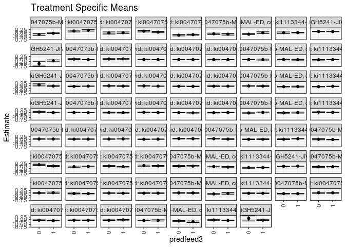

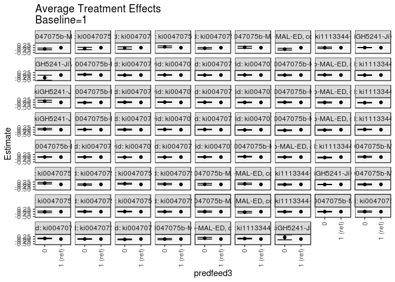

[figure not shown]

## Results Table

### Parameter: TSM

| agecat | studyid | country | intervention_level | baseline_level | estimate | ci_lower | ci_upper |
| --- | --- | --- | --- | --- | --- | --- | --- |
| 0-3 months | ki0047075b-MAL-ED | BANGLADESH | 1 | NA | -0.1043916 | -0.1414795 | -0.0673037 |
| 0-3 months | ki0047075b-MAL-ED | BANGLADESH | 0 | NA | -0.2272094 | -0.3044833 | -0.1499354 |
| 0-3 months | ki0047075b-MAL-ED | BRAZIL | 1 | NA | 0.1946806 | 0.1126523 | 0.2767088 |
| 0-3 months | ki0047075b-MAL-ED | BRAZIL | 0 | NA | 0.1152741 | 0.0274863 | 0.2030620 |
| 0-3 months | ki0047075b-MAL-ED | INDIA | 1 | NA | -0.0451923 | -0.1141066 | 0.0237220 |
| 0-3 months | ki0047075b-MAL-ED | INDIA | 0 | NA | -0.0741891 | -0.1738172 | 0.0254390 |
| 0-3 months | ki0047075b-MAL-ED | NEPAL | 1 | NA | 0.0079347 | -0.0502145 | 0.0660839 |
| 0-3 months | ki0047075b-MAL-ED | NEPAL | 0 | NA | 0.1018176 | 0.0331685 | 0.1704668 |
| 0-3 months | ki0047075b-MAL-ED | PERU | 1 | NA | -0.2436104 | -0.2853200 | -0.2019007 |
| 0-3 months | ki0047075b-MAL-ED | PERU | 0 | NA | -0.2981524 | -0.3625125 | -0.2337923 |
| 0-3 months | ki0047075b-MAL-ED | SOUTH AFRICA | 1 | NA | -0.2001432 | -0.2807943 | -0.1194921 |
| 0-3 months | ki0047075b-MAL-ED | SOUTH AFRICA | 0 | NA | -0.1578683 | -0.2200102 | -0.0957265 |
| 0-3 months | ki0047075b-MAL-ED | TANZANIA, UNITED REPUBLIC OF | 1 | NA | -0.0436497 | -0.1213507 | 0.0340513 |
| 0-3 months | ki0047075b-MAL-ED | TANZANIA, UNITED REPUBLIC OF | 0 | NA | -0.1957220 | -0.2441142 | -0.1473297 |
| 0-3 months | ki1113344-GMS-Nepal | NEPAL | 1 | NA | -0.0383851 | -0.0674235 | -0.0093466 |
| 0-3 months | ki1113344-GMS-Nepal | NEPAL | 0 | NA | -0.0432831 | -0.1095473 | 0.0229811 |
| 0-3 months | kiGH5241-JiVitA-3 | BANGLADESH | 1 | NA | 0.0586211 | 0.0522091 | 0.0650331 |
| 0-3 months | kiGH5241-JiVitA-3 | BANGLADESH | 0 | NA | 0.0709082 | 0.0547919 | 0.0870244 |
| 0-3 months | kiGH5241-JiVitA-4 | BANGLADESH | 1 | NA | -0.1880338 | -0.2823227 | -0.0937449 |
| 0-3 months | kiGH5241-JiVitA-4 | BANGLADESH | 0 | NA | -0.4624471 | -0.6994358 | -0.2254584 |
| 3-6 months | ki0047075b-MAL-ED | BANGLADESH | 1 | NA | -0.0253823 | -0.0515569 | 0.0007923 |
| 3-6 months | ki0047075b-MAL-ED | BANGLADESH | 0 | NA | -0.0001857 | -0.0521044 | 0.0517331 |
| 3-6 months | ki0047075b-MAL-ED | BRAZIL | 1 | NA | 0.0086640 | -0.0440092 | 0.0613371 |
| 3-6 months | ki0047075b-MAL-ED | BRAZIL | 0 | NA | 0.1299001 | 0.0745165 | 0.1852836 |
| 3-6 months | ki0047075b-MAL-ED | INDIA | 1 | NA | -0.0364193 | -0.0742102 | 0.0013717 |
| 3-6 months | ki0047075b-MAL-ED | INDIA | 0 | NA | -0.0590193 | -0.1176195 | -0.0004191 |
| 3-6 months | ki0047075b-MAL-ED | NEPAL | 1 | NA | -0.0620400 | -0.0971125 | -0.0269675 |
| 3-6 months | ki0047075b-MAL-ED | NEPAL | 0 | NA | 0.0057301 | -0.0338573 | 0.0453175 |
| 3-6 months | ki0047075b-MAL-ED | PERU | 1 | NA | 0.0149642 | -0.0226558 | 0.0525843 |
| 3-6 months | ki0047075b-MAL-ED | PERU | 0 | NA | 0.0446071 | -0.0121888 | 0.1014030 |

[output cut: 110 more lines]

### Parameter: E(Y)

| agecat | studyid | country | intervention_level | baseline_level | estimate | ci_lower | ci_upper |
| --- | --- | --- | --- | --- | --- | --- | --- |
| 0-3 months | ki0047075b-MAL-ED | BANGLADESH | NA | NA | -0.1272271 | -0.1614593 | -0.0929949 |
| 0-3 months | ki0047075b-MAL-ED | BRAZIL | NA | NA | 0.1488245 | 0.0885499 | 0.2090991 |
| 0-3 months | ki0047075b-MAL-ED | INDIA | NA | NA | -0.0545690 | -0.1093806 | 0.0002426 |
| 0-3 months | ki0047075b-MAL-ED | NEPAL | NA | NA | 0.0510100 | 0.0061541 | 0.0958660 |
| 0-3 months | ki0047075b-MAL-ED | PERU | NA | NA | -0.2631203 | -0.2975785 | -0.2286621 |
| 0-3 months | ki0047075b-MAL-ED | SOUTH AFRICA | NA | NA | -0.1701813 | -0.2201854 | -0.1201772 |
| 0-3 months | ki0047075b-MAL-ED | TANZANIA, UNITED REPUBLIC OF | NA | NA | -0.1481092 | -0.1901169 | -0.1061015 |
| 0-3 months | ki1113344-GMS-Nepal | NEPAL | NA | NA | -0.0389250 | -0.0654744 | -0.0123756 |
| 0-3 months | kiGH5241-JiVitA-3 | BANGLADESH | NA | NA | 0.0597934 | 0.0535906 | 0.0659963 |
| 0-3 months | kiGH5241-JiVitA-4 | BANGLADESH | NA | NA | -0.1924078 | -0.2822434 | -0.1025722 |
| 3-6 months | ki0047075b-MAL-ED | BANGLADESH | NA | NA | -0.0185754 | -0.0420362 | 0.0048853 |
| 3-6 months | ki0047075b-MAL-ED | BRAZIL | NA | NA | 0.0650837 | 0.0260851 | 0.1040822 |
| 3-6 months | ki0047075b-MAL-ED | INDIA | NA | NA | -0.0434351 | -0.0750382 | -0.0118321 |
| 3-6 months | ki0047075b-MAL-ED | NEPAL | NA | NA | -0.0255014 | -0.0523456 | 0.0013427 |
| 3-6 months | ki0047075b-MAL-ED | PERU | NA | NA | 0.0252665 | -0.0061992 | 0.0567322 |
| 3-6 months | ki0047075b-MAL-ED | SOUTH AFRICA | NA | NA | -0.0065980 | -0.0455003 | 0.0323043 |
| 3-6 months | ki0047075b-MAL-ED | TANZANIA, UNITED REPUBLIC OF | NA | NA | -0.0668448 | -0.1004432 | -0.0332465 |
| 3-6 months | ki1113344-GMS-Nepal | NEPAL | NA | NA | -0.1580566 | -0.1776900 | -0.1384232 |
| 3-6 months | kiGH5241-JiVitA-3 | BANGLADESH | NA | NA | -0.0050744 | -0.0113651 | 0.0012163 |
| 6-9 months | ki0047075b-MAL-ED | BANGLADESH | NA | NA | -0.0719928 | -0.0896446 | -0.0543410 |
| 6-9 months | ki0047075b-MAL-ED | BRAZIL | NA | NA | 0.0070906 | -0.0301925 | 0.0443736 |
| 6-9 months | ki0047075b-MAL-ED | INDIA | NA | NA | -0.0730513 | -0.0967576 | -0.0493449 |
| 6-9 months | ki0047075b-MAL-ED | NEPAL | NA | NA | -0.0334124 | -0.0530149 | -0.0138099 |
| 6-9 months | ki0047075b-MAL-ED | PERU | NA | NA | -0.0344967 | -0.0587887 | -0.0102046 |
| 6-9 months | ki0047075b-MAL-ED | SOUTH AFRICA | NA | NA | -0.0137350 | -0.0427808 | 0.0153108 |
| 6-9 months | ki0047075b-MAL-ED | TANZANIA, UNITED REPUBLIC OF | NA | NA | -0.0947719 | -0.1279445 | -0.0615994 |
| 6-9 months | ki1113344-GMS-Nepal | NEPAL | NA | NA | -0.0454089 | -0.0661443 | -0.0246735 |
| 9-12 months | ki0047075b-MAL-ED | BANGLADESH | NA | NA | -0.0853635 | -0.1017180 | -0.0690090 |
| 9-12 months | ki0047075b-MAL-ED | BRAZIL | NA | NA | 0.0033209 | -0.0300480 | 0.0366898 |
| 9-12 months | ki0047075b-MAL-ED | INDIA | NA | NA | -0.0973168 | -0.1135502 | -0.0810834 |
| 9-12 months | ki0047075b-MAL-ED | NEPAL | NA | NA | -0.0634351 | -0.0807824 | -0.0460878 |
| 9-12 months | ki0047075b-MAL-ED | PERU | NA | NA | -0.0414622 | -0.0630765 | -0.0198479 |
| 9-12 months | ki0047075b-MAL-ED | SOUTH AFRICA | NA | NA | -0.0920764 | -0.1191029 | -0.0650499 |
| 9-12 months | ki0047075b-MAL-ED | TANZANIA, UNITED REPUBLIC OF | NA | NA | -0.1543757 | -0.1899833 | -0.1187681 |
| 9-12 months | ki1113344-GMS-Nepal | NEPAL | NA | NA | -0.0793581 | -0.0958225 | -0.0628937 |
| 9-12 months | kiGH5241-JiVitA-4 | BANGLADESH | NA | NA | -0.0463035 | -0.0812128 | -0.0113943 |
| 12-15 months | ki0047075b-MAL-ED | BANGLADESH | NA | NA | -0.0541395 | -0.0699573 | -0.0383217 |
| 12-15 months | ki0047075b-MAL-ED | BRAZIL | NA | NA | -0.0004235 | -0.0234370 | 0.0225900 |
| 12-15 months | ki0047075b-MAL-ED | INDIA | NA | NA | -0.0593506 | -0.0758306 | -0.0428707 |
| 12-15 months | ki0047075b-MAL-ED | NEPAL | NA | NA | -0.0574001 | -0.0732076 | -0.0415925 |
| 12-15 months | ki0047075b-MAL-ED | PERU | NA | NA | -0.0661802 | -0.0840222 | -0.0483383 |
| 12-15 months | ki0047075b-MAL-ED | SOUTH AFRICA | NA | NA | -0.0589478 | -0.0825397 | -0.0353559 |
| 12-15 months | ki0047075b-MAL-ED | TANZANIA, UNITED REPUBLIC OF | NA | NA | -0.0678133 | -0.0945748 | -0.0410518 |
| 12-15 months | ki1113344-GMS-Nepal | NEPAL | NA | NA | -0.0698643 | -0.0805537 | -0.0591748 |
| 12-15 months | kiGH5241-JiVitA-4 | BANGLADESH | NA | NA | -0.0245445 | -0.0504325 | 0.0013435 |
| 15-18 months | ki0047075b-MAL-ED | BANGLADESH | NA | NA | -0.0458018 | -0.0595013 | -0.0321023 |
| 15-18 months | ki0047075b-MAL-ED | BRAZIL | NA | NA | -0.0272762 | -0.0493683 | -0.0051840 |
| 15-18 months | ki0047075b-MAL-ED | INDIA | NA | NA | -0.0347219 | -0.0482094 | -0.0212344 |
| 15-18 months | ki0047075b-MAL-ED | NEPAL | NA | NA | -0.0558396 | -0.0714014 | -0.0402779 |
| 15-18 months | ki0047075b-MAL-ED | PERU | NA | NA | -0.0366273 | -0.0521417 | -0.0211130 |
| 15-18 months | ki0047075b-MAL-ED | SOUTH AFRICA | NA | NA | -0.0303264 | -0.0494996 | -0.0111532 |
| 15-18 months | ki0047075b-MAL-ED | TANZANIA, UNITED REPUBLIC OF | NA | NA | -0.0885708 | -0.1125745 | -0.0645671 |
| 15-18 months | ki1113344-GMS-Nepal | NEPAL | NA | NA | -0.0623706 | -0.0756949 | -0.0490463 |
| 15-18 months | kiGH5241-JiVitA-4 | BANGLADESH | NA | NA | 0.0002451 | -0.0264873 | 0.0269774 |
| 18-21 months | ki0047075b-MAL-ED | BANGLADESH | NA | NA | -0.0156920 | -0.0275555 | -0.0038285 |
| 18-21 months | ki0047075b-MAL-ED | BRAZIL | NA | NA | -0.0173059 | -0.0423234 | 0.0077117 |
| 18-21 months | ki0047075b-MAL-ED | INDIA | NA | NA | 0.0035076 | -0.0086867 | 0.0157020 |
| 18-21 months | ki0047075b-MAL-ED | NEPAL | NA | NA | -0.0277114 | -0.0411503 | -0.0142726 |
| 18-21 months | ki0047075b-MAL-ED | PERU | NA | NA | -0.0075674 | -0.0228614 | 0.0077265 |
| 18-21 months | ki0047075b-MAL-ED | SOUTH AFRICA | NA | NA | -0.0319118 | -0.0515078 | -0.0123157 |
| 18-21 months | ki0047075b-MAL-ED | TANZANIA, UNITED REPUBLIC OF | NA | NA | -0.0280548 | -0.0527783 | -0.0033314 |
| 18-21 months | ki1113344-GMS-Nepal | NEPAL | NA | NA | 0.0192890 | 0.0050754 | 0.0335026 |
| 21-24 months | ki0047075b-MAL-ED | BANGLADESH | NA | NA | 0.0244279 | 0.0120979 | 0.0367579 |
| 21-24 months | ki0047075b-MAL-ED | BRAZIL | NA | NA | 0.0141891 | -0.0024092 | 0.0307875 |
| 21-24 months | ki0047075b-MAL-ED | INDIA | NA | NA | 0.0316867 | 0.0200407 | 0.0433327 |
| 21-24 months | ki0047075b-MAL-ED | NEPAL | NA | NA | 0.0073452 | -0.0067007 | 0.0213911 |
| 21-24 months | ki0047075b-MAL-ED | PERU | NA | NA | 0.0575837 | 0.0421321 | 0.0730353 |
| 21-24 months | ki0047075b-MAL-ED | SOUTH AFRICA | NA | NA | 0.0454561 | 0.0281790 | 0.0627333 |
| 21-24 months | ki0047075b-MAL-ED | TANZANIA, UNITED REPUBLIC OF | NA | NA | 0.0106677 | -0.0132987 | 0.0346340 |
| 21-24 months | ki1113344-GMS-Nepal | NEPAL | NA | NA | 0.0458107 | 0.0279350 | 0.0636865 |

### Parameter: ATE

| agecat | studyid | country | intervention_level | baseline_level | estimate | ci_lower | ci_upper |
| --- | --- | --- | --- | --- | --- | --- | --- |
| 0-3 months | ki0047075b-MAL-ED | BANGLADESH | 1 | 1 | 0.0000000 | 0.0000000 | 0.0000000 |
| 0-3 months | ki0047075b-MAL-ED | BANGLADESH | 0 | 1 | -0.1228178 | -0.2074561 | -0.0381794 |
| 0-3 months | ki0047075b-MAL-ED | BRAZIL | 1 | 1 | 0.0000000 | 0.0000000 | 0.0000000 |
| 0-3 months | ki0047075b-MAL-ED | BRAZIL | 0 | 1 | -0.0794064 | -0.2003359 | 0.0415230 |
| 0-3 months | ki0047075b-MAL-ED | INDIA | 1 | 1 | 0.0000000 | 0.0000000 | 0.0000000 |
| 0-3 months | ki0047075b-MAL-ED | INDIA | 0 | 1 | -0.0289968 | -0.1512330 | 0.0932394 |
| 0-3 months | ki0047075b-MAL-ED | NEPAL | 1 | 1 | 0.0000000 | 0.0000000 | 0.0000000 |
| 0-3 months | ki0047075b-MAL-ED | NEPAL | 0 | 1 | 0.0938829 | 0.0042482 | 0.1835176 |
| 0-3 months | ki0047075b-MAL-ED | PERU | 1 | 1 | 0.0000000 | 0.0000000 | 0.0000000 |
| 0-3 months | ki0047075b-MAL-ED | PERU | 0 | 1 | -0.0545420 | -0.1327970 | 0.0237130 |
| 0-3 months | ki0047075b-MAL-ED | SOUTH AFRICA | 1 | 1 | 0.0000000 | 0.0000000 | 0.0000000 |
| 0-3 months | ki0047075b-MAL-ED | SOUTH AFRICA | 0 | 1 | 0.0422749 | -0.0587798 | 0.1433295 |
| 0-3 months | ki0047075b-MAL-ED | TANZANIA, UNITED REPUBLIC OF | 1 | 1 | 0.0000000 | 0.0000000 | 0.0000000 |
| 0-3 months | ki0047075b-MAL-ED | TANZANIA, UNITED REPUBLIC OF | 0 | 1 | -0.1520723 | -0.2438166 | -0.0603279 |
| 0-3 months | ki1113344-GMS-Nepal | NEPAL | 1 | 1 | 0.0000000 | 0.0000000 | 0.0000000 |
| 0-3 months | ki1113344-GMS-Nepal | NEPAL | 0 | 1 | -0.0048981 | -0.0772767 | 0.0674806 |
| 0-3 months | kiGH5241-JiVitA-3 | BANGLADESH | 1 | 1 | 0.0000000 | 0.0000000 | 0.0000000 |
| 0-3 months | kiGH5241-JiVitA-3 | BANGLADESH | 0 | 1 | 0.0122871 | -0.0042327 | 0.0288069 |
| 0-3 months | kiGH5241-JiVitA-4 | BANGLADESH | 1 | 1 | 0.0000000 | 0.0000000 | 0.0000000 |
| 0-3 months | kiGH5241-JiVitA-4 | BANGLADESH | 0 | 1 | -0.2744133 | -0.5304260 | -0.0184006 |
| 3-6 months | ki0047075b-MAL-ED | BANGLADESH | 1 | 1 | 0.0000000 | 0.0000000 | 0.0000000 |
| 3-6 months | ki0047075b-MAL-ED | BANGLADESH | 0 | 1 | 0.0251966 | -0.0328444 | 0.0832376 |
| 3-6 months | ki0047075b-MAL-ED | BRAZIL | 1 | 1 | 0.0000000 | 0.0000000 | 0.0000000 |
| 3-6 months | ki0047075b-MAL-ED | BRAZIL | 0 | 1 | 0.1212361 | 0.0442651 | 0.1982071 |
| 3-6 months | ki0047075b-MAL-ED | INDIA | 1 | 1 | 0.0000000 | 0.0000000 | 0.0000000 |
| 3-6 months | ki0047075b-MAL-ED | INDIA | 0 | 1 | -0.0226001 | -0.0921440 | 0.0469439 |
| 3-6 months | ki0047075b-MAL-ED | NEPAL | 1 | 1 | 0.0000000 | 0.0000000 | 0.0000000 |
| 3-6 months | ki0047075b-MAL-ED | NEPAL | 0 | 1 | 0.0677701 | 0.0151181 | 0.1204220 |
| 3-6 months | ki0047075b-MAL-ED | PERU | 1 | 1 | 0.0000000 | 0.0000000 | 0.0000000 |
| 3-6 months | ki0047075b-MAL-ED | PERU | 0 | 1 | 0.0296429 | -0.0385814 | 0.0978671 |

[output cut: 110 more lines]

### Parameter: PAR

| agecat | studyid | country | intervention_level | baseline_level | estimate | ci_lower | ci_upper |
| --- | --- | --- | --- | --- | --- | --- | --- |
| 0-3 months | ki0047075b-MAL-ED | BANGLADESH | 1 | NA | -0.0228355 | -0.0393291 | -0.0063419 |
| 0-3 months | ki0047075b-MAL-ED | BRAZIL | 1 | NA | -0.0458561 | -0.1084487 | 0.0167365 |
| 0-3 months | ki0047075b-MAL-ED | INDIA | 1 | NA | -0.0093767 | -0.0470727 | 0.0283193 |
| 0-3 months | ki0047075b-MAL-ED | NEPAL | 1 | NA | 0.0430753 | -0.0001746 | 0.0863252 |
| 0-3 months | ki0047075b-MAL-ED | PERU | 1 | NA | -0.0195099 | -0.0477302 | 0.0087104 |
| 0-3 months | ki0047075b-MAL-ED | SOUTH AFRICA | 1 | NA | 0.0299620 | -0.0432120 | 0.1031359 |
| 0-3 months | ki0047075b-MAL-ED | TANZANIA, UNITED REPUBLIC OF | 1 | NA | -0.1044595 | -0.1707887 | -0.0381303 |
| 0-3 months | ki1113344-GMS-Nepal | NEPAL | 1 | NA | -0.0005399 | -0.0128564 | 0.0117765 |
| 0-3 months | kiGH5241-JiVitA-3 | BANGLADESH | 1 | NA | 0.0011724 | -0.0004250 | 0.0027697 |
| 0-3 months | kiGH5241-JiVitA-4 | BANGLADESH | 1 | NA | -0.0043740 | -0.0330017 | 0.0242537 |
| 3-6 months | ki0047075b-MAL-ED | BANGLADESH | 1 | NA | 0.0068069 | -0.0037256 | 0.0173393 |
| 3-6 months | ki0047075b-MAL-ED | BRAZIL | 1 | NA | 0.0564197 | 0.0173168 | 0.0955227 |
| 3-6 months | ki0047075b-MAL-ED | INDIA | 1 | NA | -0.0070159 | -0.0272589 | 0.0132271 |
| 3-6 months | ki0047075b-MAL-ED | NEPAL | 1 | NA | 0.0365385 | 0.0095195 | 0.0635576 |
| 3-6 months | ki0047075b-MAL-ED | PERU | 1 | NA | 0.0103023 | -0.0127055 | 0.0333101 |
| 3-6 months | ki0047075b-MAL-ED | SOUTH AFRICA | 1 | NA | 0.0013599 | -0.0606856 | 0.0634055 |
| 3-6 months | ki0047075b-MAL-ED | TANZANIA, UNITED REPUBLIC OF | 1 | NA | 0.0364608 | -0.0163181 | 0.0892396 |
| 3-6 months | ki1113344-GMS-Nepal | NEPAL | 1 | NA | -0.0033688 | -0.0123469 | 0.0056093 |
| 3-6 months | kiGH5241-JiVitA-3 | BANGLADESH | 1 | NA | -0.0012571 | -0.0030526 | 0.0005384 |
| 6-9 months | ki0047075b-MAL-ED | BANGLADESH | 1 | NA | -0.0011117 | -0.0099569 | 0.0077335 |
| 6-9 months | ki0047075b-MAL-ED | BRAZIL | 1 | NA | -0.0042752 | -0.0427078 | 0.0341574 |
| 6-9 months | ki0047075b-MAL-ED | INDIA | 1 | NA | 0.0028270 | -0.0124240 | 0.0180780 |
| 6-9 months | ki0047075b-MAL-ED | NEPAL | 1 | NA | 0.0075056 | -0.0123317 | 0.0273429 |
| 6-9 months | ki0047075b-MAL-ED | PERU | 1 | NA | 0.0005268 | -0.0174118 | 0.0184654 |
| 6-9 months | ki0047075b-MAL-ED | SOUTH AFRICA | 1 | NA | -0.0009428 | -0.0483277 | 0.0464420 |
| 6-9 months | ki0047075b-MAL-ED | TANZANIA, UNITED REPUBLIC OF | 1 | NA | -0.0338280 | -0.0908905 | 0.0232344 |
| 6-9 months | ki1113344-GMS-Nepal | NEPAL | 1 | NA | -0.0007154 | -0.0085384 | 0.0071077 |
| 9-12 months | ki0047075b-MAL-ED | BANGLADESH | 1 | NA | 0.0007332 | -0.0058785 | 0.0073449 |
| 9-12 months | ki0047075b-MAL-ED | BRAZIL | 1 | NA | 0.0029959 | -0.0304311 | 0.0364230 |
| 9-12 months | ki0047075b-MAL-ED | INDIA | 1 | NA | 0.0183940 | 0.0076222 | 0.0291657 |
| 9-12 months | ki0047075b-MAL-ED | NEPAL | 1 | NA | 0.0014213 | -0.0163905 | 0.0192331 |
| 9-12 months | ki0047075b-MAL-ED | PERU | 1 | NA | -0.0117754 | -0.0270446 | 0.0034937 |
| 9-12 months | ki0047075b-MAL-ED | SOUTH AFRICA | 1 | NA | -0.0096563 | -0.0570486 | 0.0377360 |
| 9-12 months | ki0047075b-MAL-ED | TANZANIA, UNITED REPUBLIC OF | 1 | NA | 0.0564235 | -0.0019741 | 0.1148212 |
| 9-12 months | ki1113344-GMS-Nepal | NEPAL | 1 | NA | 0.0083101 | 0.0020998 | 0.0145204 |
| 9-12 months | kiGH5241-JiVitA-4 | BANGLADESH | 1 | NA | 0.0075242 | -0.0074571 | 0.0225054 |
| 12-15 months | ki0047075b-MAL-ED | BANGLADESH | 1 | NA | 0.0089685 | -0.0001798 | 0.0181168 |
| 12-15 months | ki0047075b-MAL-ED | BRAZIL | 1 | NA | -0.0056944 | -0.0278482 | 0.0164595 |
| 12-15 months | ki0047075b-MAL-ED | INDIA | 1 | NA | 0.0031556 | -0.0075370 | 0.0138483 |
| 12-15 months | ki0047075b-MAL-ED | NEPAL | 1 | NA | -0.0004130 | -0.0169105 | 0.0160846 |
| 12-15 months | ki0047075b-MAL-ED | PERU | 1 | NA | 0.0027443 | -0.0106381 | 0.0161267 |
| 12-15 months | ki0047075b-MAL-ED | SOUTH AFRICA | 1 | NA | -0.0012255 | -0.0439561 | 0.0415051 |
| 12-15 months | ki0047075b-MAL-ED | TANZANIA, UNITED REPUBLIC OF | 1 | NA | 0.0015647 | -0.0360333 | 0.0391628 |
| 12-15 months | ki1113344-GMS-Nepal | NEPAL | 1 | NA | -0.0011581 | -0.0062830 | 0.0039667 |
| 12-15 months | kiGH5241-JiVitA-4 | BANGLADESH | 1 | NA | 0.0056021 | -0.0028449 | 0.0140491 |
| 15-18 months | ki0047075b-MAL-ED | BANGLADESH | 1 | NA | -0.0046378 | -0.0109330 | 0.0016573 |
| 15-18 months | ki0047075b-MAL-ED | BRAZIL | 1 | NA | 0.0071624 | -0.0146026 | 0.0289273 |
| 15-18 months | ki0047075b-MAL-ED | INDIA | 1 | NA | 0.0077043 | -0.0023172 | 0.0177259 |
| 15-18 months | ki0047075b-MAL-ED | NEPAL | 1 | NA | 0.0063667 | -0.0095952 | 0.0223285 |
| 15-18 months | ki0047075b-MAL-ED | PERU | 1 | NA | 0.0065358 | -0.0058387 | 0.0189104 |
| 15-18 months | ki0047075b-MAL-ED | SOUTH AFRICA | 1 | NA | 0.0066401 | -0.0272832 | 0.0405633 |
| 15-18 months | ki0047075b-MAL-ED | TANZANIA, UNITED REPUBLIC OF | 1 | NA | -0.0057798 | -0.0435742 | 0.0320147 |
| 15-18 months | ki1113344-GMS-Nepal | NEPAL | 1 | NA | -0.0056420 | -0.0098772 | -0.0014069 |
| 15-18 months | kiGH5241-JiVitA-4 | BANGLADESH | 1 | NA | 0.0076208 | -0.0014765 | 0.0167181 |
| 18-21 months | ki0047075b-MAL-ED | BANGLADESH | 1 | NA | 0.0030399 | -0.0019774 | 0.0080573 |
| 18-21 months | ki0047075b-MAL-ED | BRAZIL | 1 | NA | 0.0018547 | -0.0228763 | 0.0265857 |
| 18-21 months | ki0047075b-MAL-ED | INDIA | 1 | NA | 0.0055289 | -0.0030853 | 0.0141430 |
| 18-21 months | ki0047075b-MAL-ED | NEPAL | 1 | NA | 0.0083135 | -0.0053835 | 0.0220104 |
| 18-21 months | ki0047075b-MAL-ED | PERU | 1 | NA | -0.0068401 | -0.0174911 | 0.0038108 |
| 18-21 months | ki0047075b-MAL-ED | SOUTH AFRICA | 1 | NA | -0.0402063 | -0.0758003 | -0.0046123 |
| 18-21 months | ki0047075b-MAL-ED | TANZANIA, UNITED REPUBLIC OF | 1 | NA | -0.0220140 | -0.0613554 | 0.0173274 |
| 18-21 months | ki1113344-GMS-Nepal | NEPAL | 1 | NA | 0.0023090 | -0.0022139 | 0.0068319 |
| 21-24 months | ki0047075b-MAL-ED | BANGLADESH | 1 | NA | 0.0009528 | -0.0039142 | 0.0058198 |
| 21-24 months | ki0047075b-MAL-ED | BRAZIL | 1 | NA | -0.0018532 | -0.0180640 | 0.0143576 |
| 21-24 months | ki0047075b-MAL-ED | INDIA | 1 | NA | -0.0042718 | -0.0123515 | 0.0038079 |
| 21-24 months | ki0047075b-MAL-ED | NEPAL | 1 | NA | -0.0061397 | -0.0200172 | 0.0077379 |
| 21-24 months | ki0047075b-MAL-ED | PERU | 1 | NA | 0.0017475 | -0.0095776 | 0.0130726 |
| 21-24 months | ki0047075b-MAL-ED | SOUTH AFRICA | 1 | NA | 0.0288323 | -0.0018352 | 0.0594997 |
| 21-24 months | ki0047075b-MAL-ED | TANZANIA, UNITED REPUBLIC OF | 1 | NA | 0.0070308 | -0.0283891 | 0.0424507 |
| 21-24 months | ki1113344-GMS-Nepal | NEPAL | 1 | NA | -0.0067428 | -0.0134447 | -0.0000410 |